# Lecture 3.3 - Practicing Hypotheses Tests

Author

Student

Published

September 28, 2026

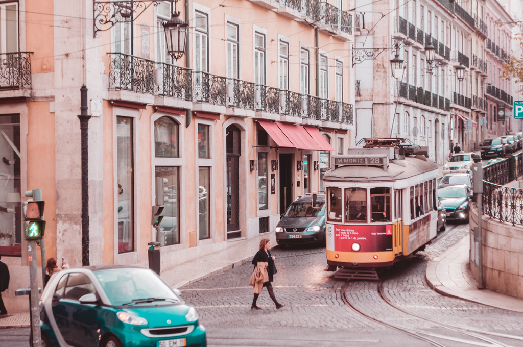

# Hypothesis Testing

## Setting Expectations

Included is a dataset regarding student drinking habits and other student characteristics from a 2008 survey of Portugese high school students.

Some basic facts about Europe:

- According to a paper titled, “Youth Drinking Rates and Problems: A Comparison of European Countries and the United States” by Friese and Grube, the average problem drinking rate in Europe is about 19%.
- According to https://www.statista.com/statistics/377585/household-internet-access-in-eu28/, in 2008, the number of households in Europe with Internet access was about 60%
- According to http://strongerfamilies.eu/about-us-2/one-parent-families-in-europe/, about 10% of families in Europe are single-parent families
- According to https://www.pewinternet.org/2015/10/01/basics-of-teen-romantic-relationships/, about 19% of US students are in a romantic relationship

## Setup and Data Exploration

1. What are the variables that map to these outcomes in your dataset?

For the following questions, make a small table:

2. What is the percentage of problem drinkers in the sample?

> Note that student drinking is measured on a 1-5 scale. You can make a two-category version by using the `mutate` verb and `case_when()` as follows:

```
student.drinking.cleaned <- student.drinking.cleaned %>%
  mutate(problem.drinking = case_when(alcohol.use < 4 ~ 0,
                                      alcohol.use >= 4 ~ 1))
```

## Planning

Pick one of the variables from questions 2-5. For this variable, consider the following questions:

6. What, in your opinion, would be a substantively significant difference in this mean/proportion? How large would a difference need to be for you to consider it meaningful? Make some notes about this.
7. Are the conditions satisfied for conducting a hypothesis test? Why or why not?
8. What, in your opinion, should Portuguese policymakers do if you judge the the mean/proportion in your data are significantly different than world averages? Make some notes about this.

## Calculation

9. Write a fully specified hypothesis using a 95% cutoff.
10. Calculate the $p$ value for your hypothesis and and indicate whether you reject or fail to reject the null hypothesis

## Interpretation

11. Write a paragraph describing your results and also what kind of policy reforms you would recommend to policymakers based on the results of your hypotheses tests

## Extra

Repeat the process for any of the other variables from questions 2-5 that you did not consider in the first round.